# Homework 8

# Yuxin Sun

## Results

### 1. My Own Implementation

Figure 1: `MyGRU`, `lr=1e-3`, `betas=(0.85,0.9)`

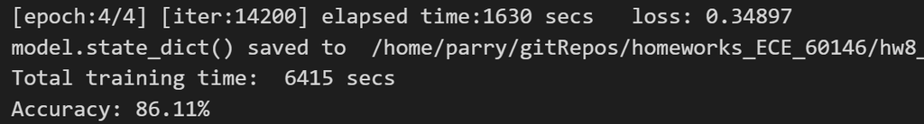

The accuracy is $86.11\%$.

Figure 2: Loss

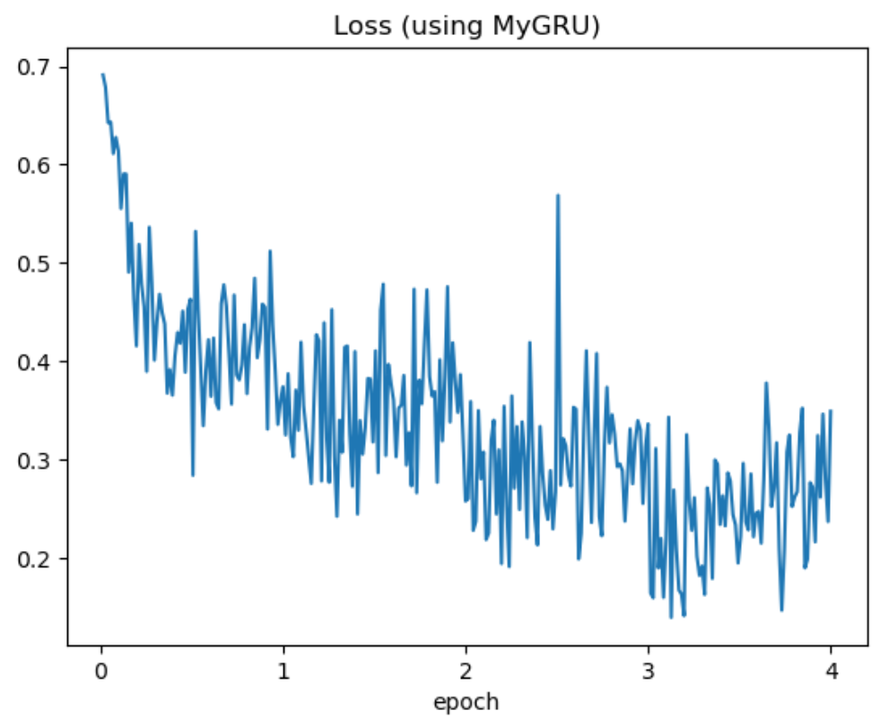

Figure 3: Confusion Matrix

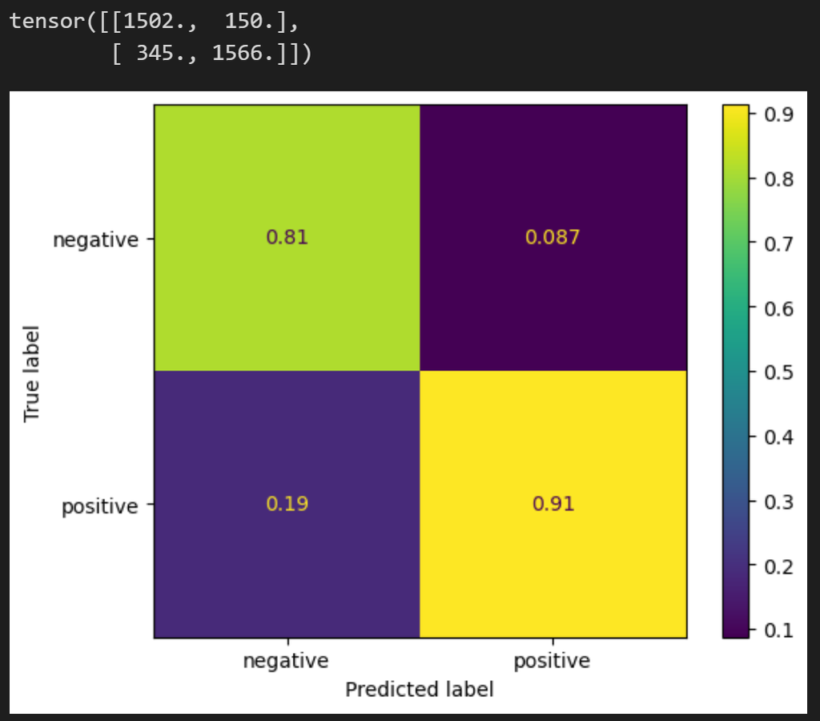

### 2. Using `nn.GRU`

Figure `nn.GRU(bidirectional=False)`

Figure 4: `nn.GRU`, `lr=1e-3`, `betas=(0.85,0.9)`

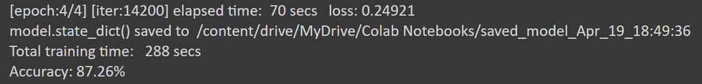

The accuracy is $87.26\%$.

Figure 5: Loss

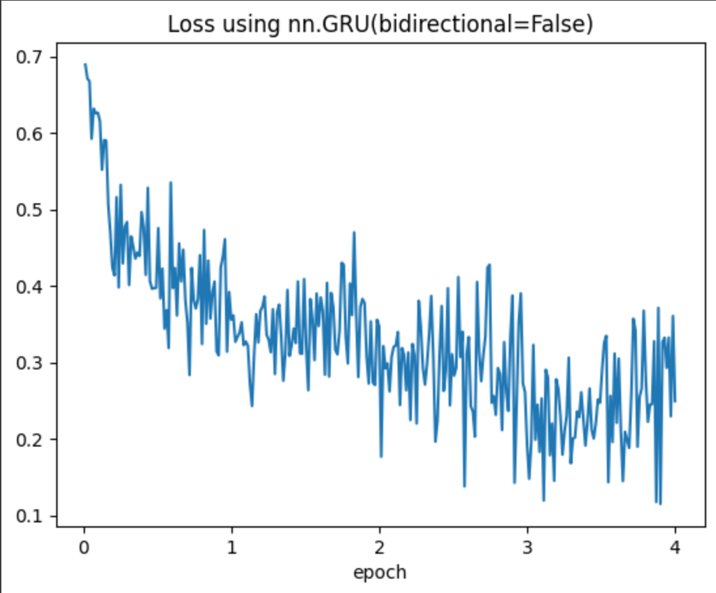

Figure 6: Confusion Matrix

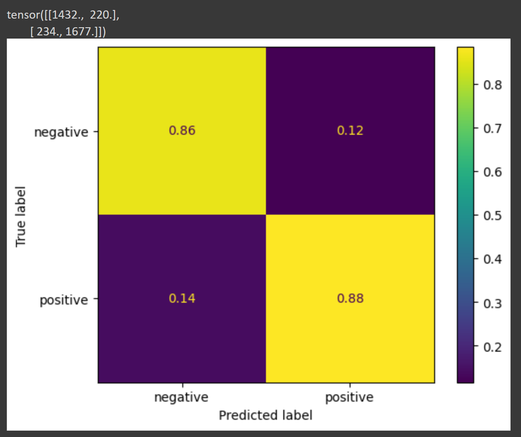

### 3. Using `nn.GRU` with `bidirectional=True`

Figure 7: `nn.GRU(bidirectional=True)`, `lr=1e-3`, `betas=(0.85,0.9)`

[figure not shown]

The accuracy is $86.70\%$.

Figure 8: Loss

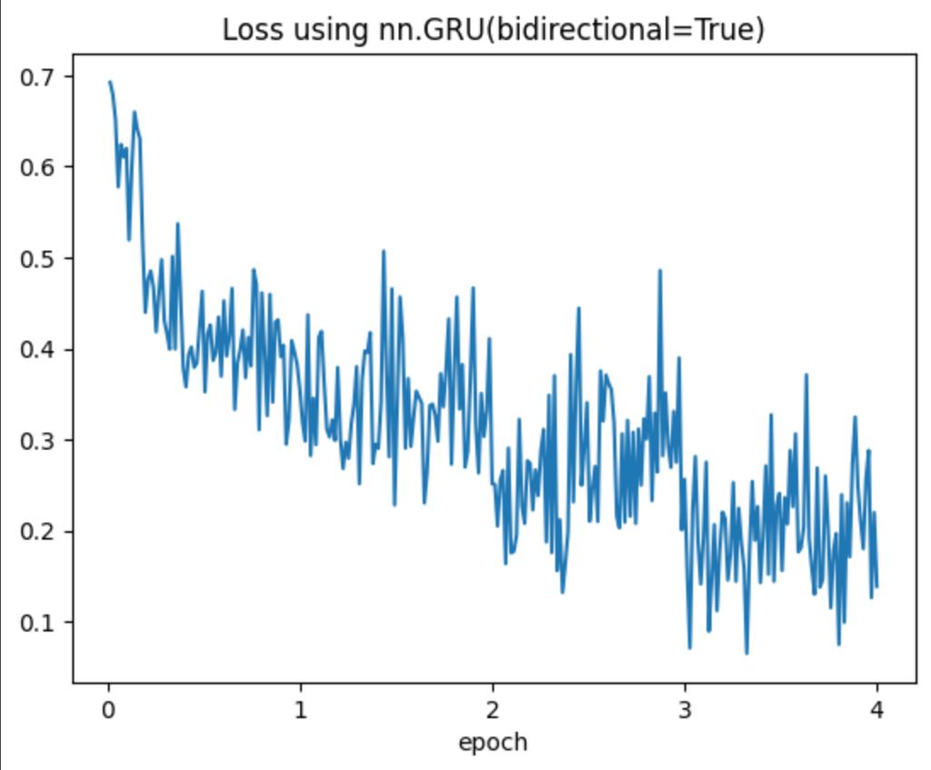

Figure 9: Confusion Matrix

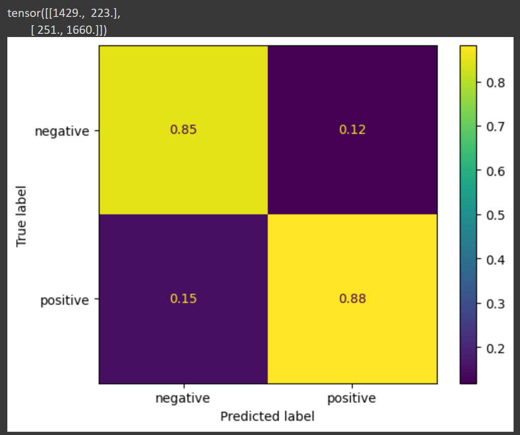

## Code

### MyGRU

By following equations on Prof. Kak's slides, I have:

```
class MyGRU(nn.Module):
    def __init__(self, input_size, hidden_size) -> None:
        super().__init__()
        self.input_size = input_size
        self.hidden_size = hidden_size
        # bias = True
        self.Wz = nn.Linear(self.input_size, self.hidden_size)
        self.Wr = nn.Linear(self.input_size, self.hidden_size)
        self.Wh = nn.Linear(self.input_size, self.hidden_size)
        self.Uz = nn.Linear(self.hidden_size, self.hidden_size)
        self.Ur = nn.Linear(self.hidden_size, self.hidden_size)
        self.Uh = nn.Linear(self.hidden_size, self.hidden_size)
        self.sigm = nn.Sigmoid()
        self.tanh = nn.Tanh()

    def forward(self, x, h):
        z = self.sigm(self.Wz(x) + self.Uz(h))
        r = self.sigm(self.Wr(x) + self.Ur(h))
        ht= self.tanh(self.Wh(x) + self.Uh(h*r))            # ht means \tilde{h}
        h_next = h + z*(ht-h)
        output = h_next
        return output, h_next
```

### RNN

I wrap my GRU into a RNN class. It takes in all the words in a review and returns a 2D sentiment vector.

```
class RNN_1(nn.Module):
    def __init__(self, input_size, hidden_size, output_size, *, device="cpu"):
        super().__init__()
        self.input_size = input_size
        self.hidden_size = hidden_size
        self.output_size = output_size
        self.device = device

        self.gru = MyGRU(input_size, hidden_size)
        self.fc = nn.Linear(hidden_size, output_size)
        self.relu = nn.ReLU()

    def forward(self, input):
        hidden = self.init_hidden()
        for k in range(input.shape[1]):
            output, hidden = self.gru(input[0,k].unsqueeze(dim=0), hidden)
        output = self.fc(self.relu(output))
        # there is no LogSoftMax here,
        # so we should use CrossEntropyLoss as our criterion.
        return output

    # from Prof Kak's code
    def init_hidden(self):
        # hidden = weight.new(1, self.hidden_size).zero_()
        hidden = torch.zeros(1, self.hidden_size, dtype=torch.float, device=self.device)
        return hidden
```

The `nn.GRU` is also wrapped into a RNN:

```
class RNN_2(nn.Module):
    def __init__(self, input_size, hidden_size, output_size, *, device="cpu", bidirectional=False):
        super().__init__()
        self.input_size = input_size
        self.hidden_size = hidden_size
        self.output_size = output_size
        self.device = device
        self.num_layers = 1
        self.bidirectional = bidirectional

        # self.gru = MyGRU(input_size, hidden_size)
        self.gru = nn.GRU(input_size, hidden_size, self.num_layers, batch_first=True, bidirectional=bidirectional)
        self.fc = nn.Linear(hidden_size * (2 if self.bidirectional else 1), output_size)
        self.relu = nn.ReLU()

    def forward(self, input):
        hidden = self.init_hidden()
        output, hidden = self.gru(input, hidden)
        hidden = hidden.reshape(1,-1)
        output = self.fc(self.relu(hidden))
        return output
```

## Discussion

#### 1. how I think the problem of vanishing gradients is mitigated with the gating mechanism?

`h_next = h + z*(ht-h)`

Above formula is similar to `ResNet` which uses original information `h` plus certain new information `z*(ht-h)` from a block. The original information can go deep into the network and shorten the effective depth of the network.

Besides, there's a simple observation that if gate $z$ is close to zero, then the previous hidden state `h` will remain almost unchanged. I guess the hidden state will not change much if we feed in an irrelevant word. This behavior may also make the effective depth of RNN smaller.

#### 2. Does using bidirectional scan make a difference?

There is no big difference in my homework.

#### 3. performance of the three RNNs.

All these three RNNs have an accuracy around $86\%$. So we can say they have the same accuracy.

I found that `nn.GRU` runs much faster than my own implementation. There may be many optimizations in `nn.GRU`, or that it is just better if we feed in an entire sequence.